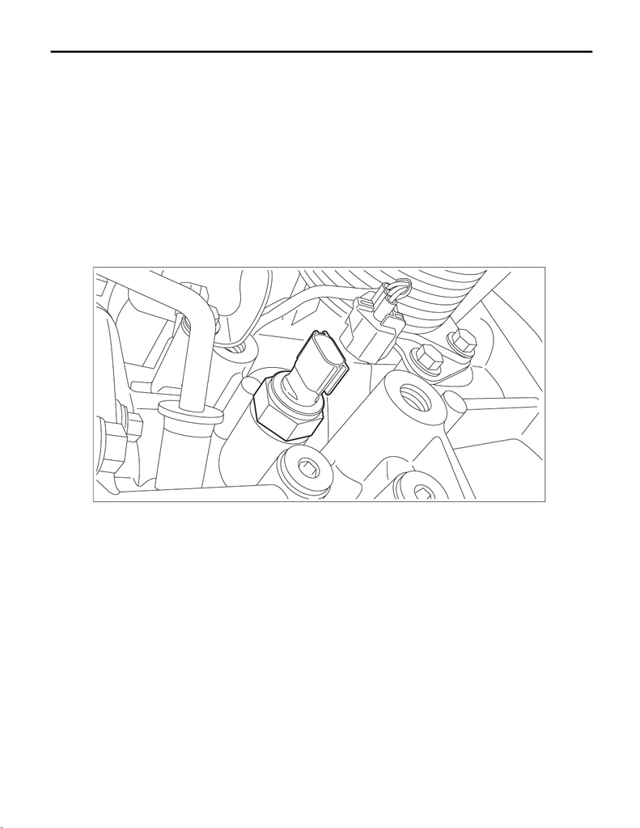

CVT(TR690)-110

Secondary Pressure Sensor

CONTINUOUSLY VARIABLE TRANSMISSION

19.Secondary Pressure Sensor

A: REMOVAL

CAUTION:

• When removing secondary pressure sensor, CVTF may let out. If CVTF has leaked, adjust the CVTF

level after installing the secondary pressure sensor.

1) Disconnect the ground terminal from battery sensor. <Ref. to NT-5, BATTERY, NOTE, Note.>

2) Lift up the vehicle.

3) Clean the transmission exterior.

4) Remove the secondary pressure sensor harness connector.

5) Remove the secondary pressure sensor.

NOTE:

Use Ko-ken 3/8 12-point 27 mm (manufacturer product No. 3305M-27) deep socket.

B: INSTALLATION

CAUTION:

• After installing the secondary pressure sensor, adjust the CVTF level.

Install in the reverse order of removal.

NOTE:

Use new O-rings.

Tightening torque:

39 N·m (4.0 kgf-m, 28.8 ft-lb)

AT-07838

[figure not shown]

CVT(TR690)-111

Secondary Pressure Sensor

CONTINUOUSLY VARIABLE TRANSMISSION

C: INSPECTION

1) Start and warm up the engine.

2) Shift the select lever to “P” or “N” range.

3) Depress the brake pedal and hold it.

4) Check “secondary pressure sensor voltage” by using Subaru Select Monitor while the engine is idling.

<Ref. to CVT(diag)-14, OPERATION, Subaru Select Monitor.>

Specification:

Approx. 0.8 V

5) Check “secondary pressure sensor voltage” by using Subaru Select Monitor while the engine is stopped

and the ignition switch is turned on. <Ref. to CVT(diag)-14, OPERATION, Subaru Select Monitor.>

Specification:

Approx. 0.5 V